# Gender and affiliation diversity in philosophy of science

Guglielmo Sproloquio

# Setup

We begin by loading the libraries and importing the tables we need.

Paths are resolved from the repository root with `here::here()`. The SOPHIS tables are **not** versioned: place them in `data/` (see `data/README.md`).

```r
library(broom.mixed)   # tidy() for the IRR table
library(dplyr)
library(tidyr)
library(ggplot2)
library(ggpmisc)       # R^2 annotations
library(readr)
library(fixest)        # fixed-effects negative binomial regression
library(vegan)         # Shannon entropy
library(reactable)
library(ggrepel)
library(modelsummary)
library(here)

data_dir <- here("data")

read_table <- function(name) {
  read.csv(file.path(data_dir, paste0(name, ".csv")))
}

article     <- read_table("article")
actor       <- read_table("actor")
affiliation <- read_table("affiliation")
authorship  <- read_table("authorship")
mention     <- read_table("mention")
prize       <- read_table("prize")
association <- read_table("association")
clustering  <- read_table("clustering")
cluster     <- read_table("cluster")   # sub-field labels

research_articles <- read_delim(
  file.path(data_dir, "6826_Research_Articles.csv"),
  delim = ";", escape_double = FALSE, trim_ws = TRUE,
  show_col_types = FALSE
)
```

# Preliminaries

We merge authors and acknowledgees of articles in a single category called “contributors”.

```r
# Authors and acknowledgees in a single table
authors_set <- authorship %>%
  select(UT, H_ID) %>%
  mutate(contribution_type = "Author")

ackgees_set <- mention %>%
  filter(H_ID != "") %>%
  select(UT, H_ID) %>%
  mutate(contribution_type = "Acknowledgee")

contributions <- rbind(authors_set, ackgees_set) %>%
  arrange(UT, desc(contribution_type)) %>%
  rename(contributor = H_ID)
```

We assign gender and affiliation to each contributor.

```r
# Contributors' affiliation, matched on the article's publication year
cont_with_aff <- contributions %>%
  left_join(article %>% select(UT, Pub_Year), by = "UT") %>%
  left_join(affiliation, by = c("contributor" = "H_ID", "Pub_Year" = "Year"))

university <- cont_with_aff %>%
  filter(!is.na(Inst_ID)) %>%
  group_by(UT) %>%
  summarise(
    n_universities = n_distinct(Inst_ID),
    universities   = list(unique(Inst_ID)),
    .groups = "drop"
  )

# In another table we assign contributors' gender
gender <- contributions %>%
  left_join(actor %>% select(H_ID, Gender), by = c("contributor" = "H_ID")) %>%
  filter(Gender != "") %>%
  group_by(UT) %>%
  summarise(
    n_generi = n_distinct(Gender),
    generi   = list(unique(Gender)),
    .groups  = "drop"
  )
```

We add the total number of citations received by each article and merge all the information in a single table. Importantly, we keep only articles with **more than one contributor** (team size > 1).

```r
# Total citations per article
citations <- research_articles %>%
  select(UT, TC)

# Articles, number of contributors, gender, affiliations and citations
div_article <- article %>%
  left_join(
    contributions %>%
      group_by(UT) %>%
      summarise(
        conts   = list(unique(contributor)),
        n_conts = n_distinct(contributor),
        .groups = "drop"
      ),
    by = "UT"
  ) %>%
  left_join(university, by = "UT") %>%
  left_join(gender, by = "UT") %>%
  left_join(citations, by = "UT") %>%
  filter(n_conts > 1) %>%   # <- team size > 1
  select(UT, Pub_Year, Journal_Complete, conts, n_conts,
         universities, n_universities, generi, n_generi, TC)

nrow(div_article)
```

```
## [1] 5174
```

A 10-row preview of the table (the full table is deliberately not embedded in the report, so that the published page does not redistribute the underlying records):

```r
div_article %>%
  select(-conts, -universities, -generi) %>%
  slice_head(n = 10) %>%
  reactable()
```

| UT | Pub_Year | Journal_Complete | n_conts | n_universities | n_generi | TC |
| --- | --- | --- | --- | --- | --- | --- |
| WOS:000237909800004 | 2005 | ERKENNTNIS | 10 | 7 | 2 | 21 |
| WOS:000237909800005 | 2005 | ERKENNTNIS | 2 | 2 | 1 | 13 |
| WOS:000237909800006 | 2005 | ERKENNTNIS | 5 | 4 | 1 | 17 |
| WOS:000237909800007 | 2005 | ERKENNTNIS | 3 | 3 | 1 | 15 |
| WOS:000229099400001 | 2005 | ERKENNTNIS | 5 | 1 | 1 | 2 |
| WOS:000229099400003 | 2005 | ERKENNTNIS | 8 | 4 | 1 | 10 |
| WOS:000229099400004 | 2005 | ERKENNTNIS | 2 | 1 | 1 | 3 |
| WOS:000229099400005 | 2005 | ERKENNTNIS | 3 | 3 | 2 | 39 |
| WOS:000232054500001 | 2005 | ERKENNTNIS | 4 | 2 | 2 | 7 |
| WOS:000232054500002 | 2005 | ERKENNTNIS | 15 | 10 | 2 | 1 |

A quick diagnostic: how many (article, person) pairs appear more than once among the contributors? This happens, for instance, when the same person is both author and acknowledgee of the same article. Such pairs count once in `n_conts` (which uses `n_distinct()`) but twice in the gender and affiliation counts below.

```r
contributions %>%
  count(UT, contributor) %>%
  filter(n > 1) %>%
  nrow()
```

```
## [1] 6
```

# First insights

## Descriptive statistics table

Here we compile some descriptive statistics in absolute terms.

```r
# Contributor-type stats
stats_cont <- contributions %>%
  group_by(UT) %>%
  summarise(
    n_authors      = sum(contribution_type == "Author"),
    n_acknowledges = sum(contribution_type == "Acknowledgee"),
    # guard against articles with acknowledgees but no listed author (would be Inf)
    acks_per_author = if_else(n_authors > 0, n_acknowledges / n_authors, NA_real_),
    .groups = "drop"
  ) %>%
  filter(n_authors + n_acknowledges > 1)

# Descriptive table
div_article %>%
  left_join(stats_cont, by = "UT") %>%
  summarise(
    mean_team_size                  = mean(n_conts),
    median_team_size                = median(n_conts),
    mean_acknowledgees_per_author   = mean(acks_per_author, na.rm = TRUE),
    median_acknowledgees_per_author = median(acks_per_author, na.rm = TRUE),
    perc_mixed_gender       = sum(n_generi == 2, na.rm = TRUE) / sum(!is.na(n_generi)),
    perc_between_uni_collab = sum(n_universities > 1, na.rm = TRUE) / sum(!is.na(n_universities)),
    mean_citations   = mean(TC, na.rm = TRUE),
    median_citations = median(TC, na.rm = TRUE)
  ) %>%
  reactable()
```

| mean_team_size | median_team_size | mean_acknowledgees_per_author | median_acknowledgees_per_author | perc_mixed_gender | perc_between_uni_collab | mean_citations | median_citations |
| --- | --- | --- | --- | --- | --- | --- | --- |
| 6.07866254348666 | 5 | 4.37096294966898 | 3 | 0.575956706609973 | 0.880837047083898 | 15.3533732843611 | 8 |

…and over the years.

```r
div_article %>%
  group_by(Pub_Year) %>%
  summarise(
    mean_team_size_per_year   = mean(n_conts),
    median_team_size_per_year = median(n_conts),
    perc_mixed_gender_per_year =
      sum(n_generi == 2, na.rm = TRUE) / sum(!is.na(n_generi)),
    perc_between_uni_collab_per_year =
      sum(n_universities > 1, na.rm = TRUE) / sum(!is.na(n_universities)),
    mean_citations_per_year   = mean(TC, na.rm = TRUE),
    median_citations_per_year = median(TC, na.rm = TRUE)
  ) %>%
  reactable()
```

| Pub_Year | mean_team_size_per_year | median_team_size_per_year | perc_mixed_gender_per_year | perc_between_uni_collab_per_year | mean_citations_per_year | median_citations_per_year |
| --- | --- | --- | --- | --- | --- | --- |
| 2005 | 5.72058823529412 | 5 | 0.5 | 0.824120603015075 | 18.2413793103448 | 9 |
| 2006 | 5.88888888888889 | 5 | 0.579710144927536 | 0.869565217391304 | 23.0676328502415 | 11 |
| 2007 | 5.56779661016949 | 5 | 0.516949152542373 | 0.851694915254237 | 26.1483050847458 | 12 |
| 2008 | 5.44769874476987 | 4 | 0.552301255230126 | 0.823529411764706 | 19.4058577405858 | 10 |
| 2009 | 5.91785714285714 | 5 | 0.553571428571429 | 0.864285714285714 | 21.4607142857143 | 10.5 |
| 2010 | 5.86524822695035 | 5 | 0.553191489361702 | 0.886524822695035 | 23.4822695035461 | 12 |
| 2011 | 6.12209302325581 | 5 | 0.534883720930233 | 0.87463556851312 | 17.3023255813953 | 10 |
| 2012 | 6.07758620689655 | 5 | 0.600574712643678 | 0.904624277456647 | 16.4511494252874 | 10 |
| 2013 | 5.74200913242009 | 5 | 0.54337899543379 | 0.869565217391304 | 15.5365296803653 | 9 |
| 2014 | 6.42984409799555 | 5 | 0.56347438752784 | 0.892857142857143 | 13.3340757238307 | 8 |

[output cut: 5 more lines]

## Team size and type of contribution

Here we plot the cumulative distribution of the number of authors, the number of acknowledgees and the total team size, and the frequency of team sizes. By far the most frequent number of authors is 1, while the number of acknowledgees is more spread out, even if smaller amounts are more frequent. The minimum team size is 2, since we kept only teams with at least two contributors, and smaller teams are more frequent.

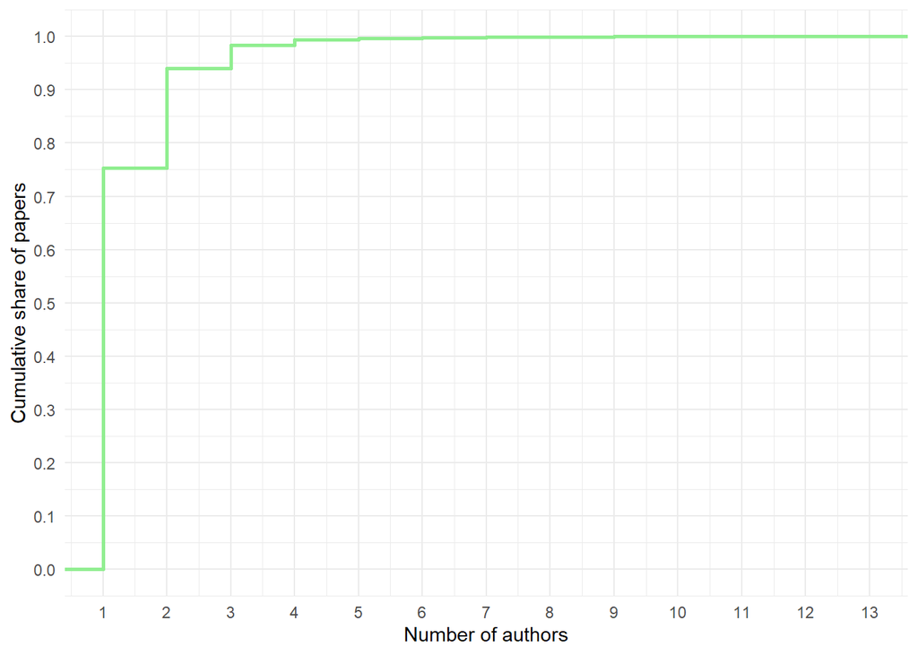

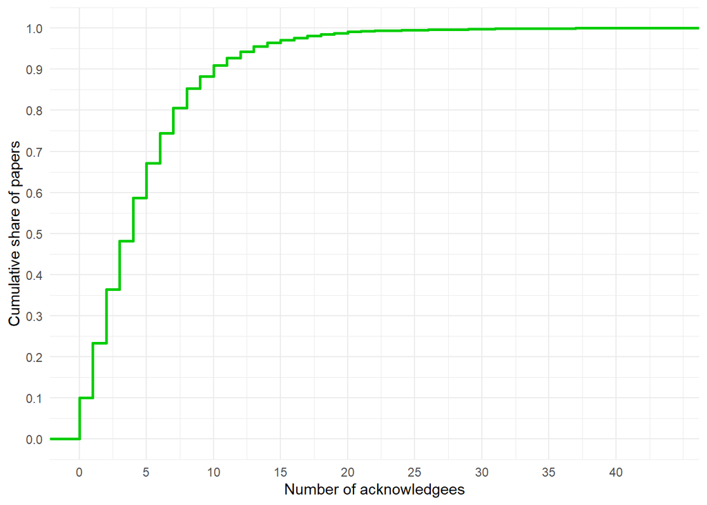

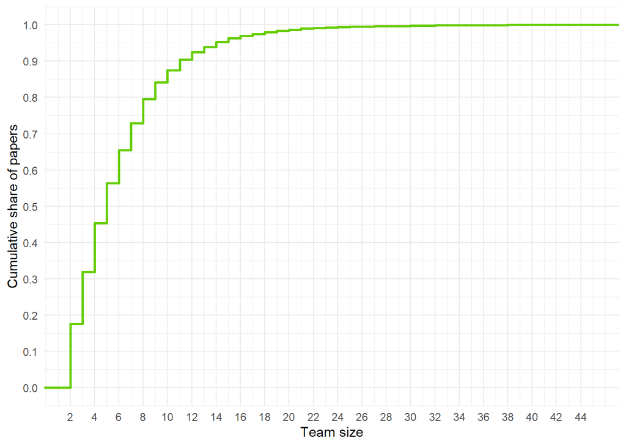

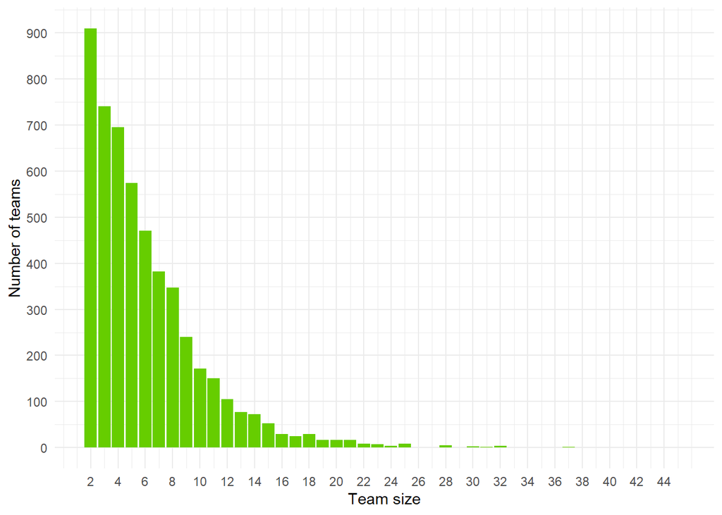

## Contribution type over team size

As team size increases, generally fewer contributors are acknowledgees and more are authors. This supports the idea that part of the differences in team size are due to differences in authorship practices.

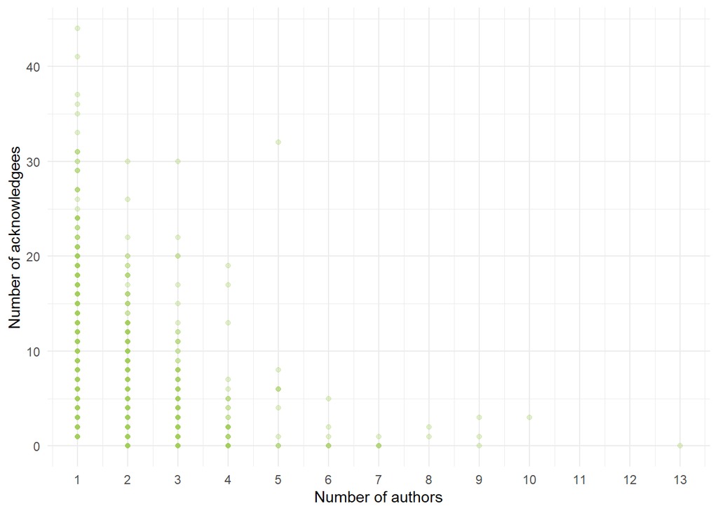

## Team size over the years

There is a small increase of the mean team size over the years. The same pattern is observed using only authors as the measure of team size, which gives more confidence in the reliability of the method.

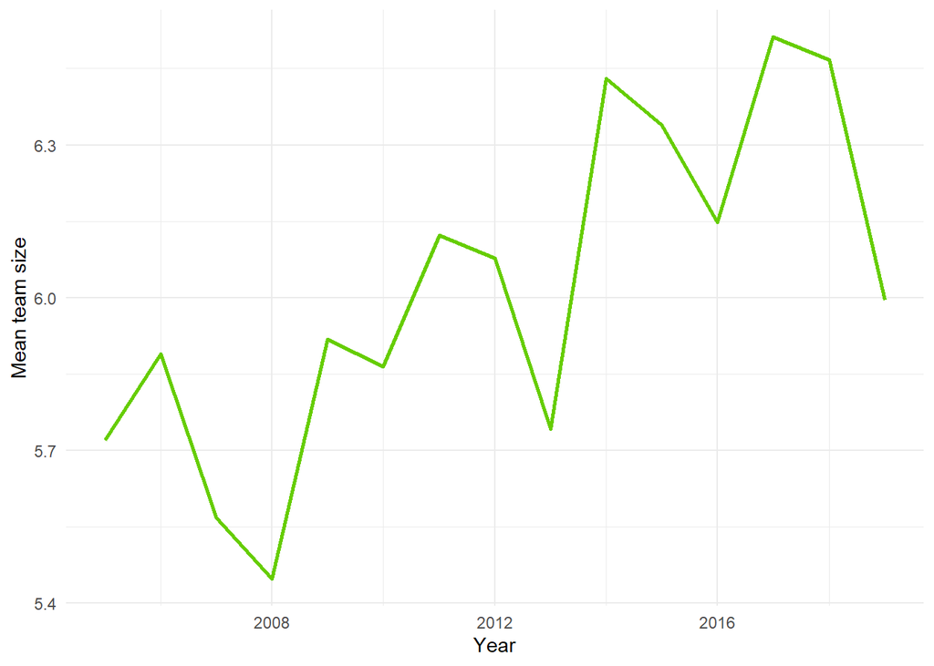

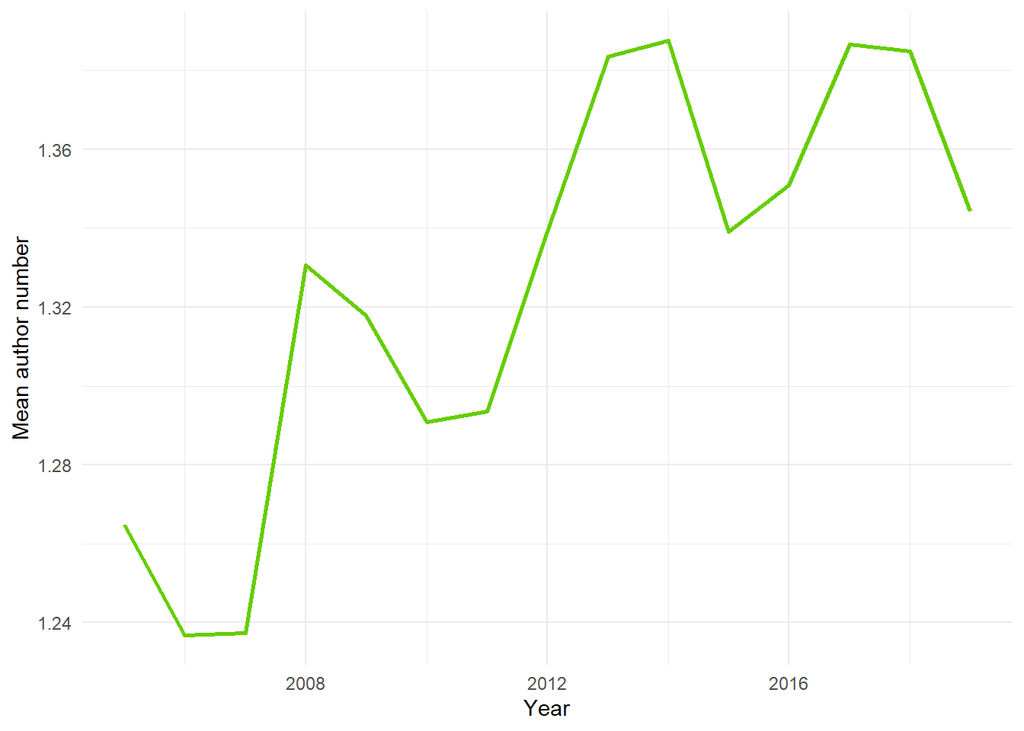

## Gender composition

We now inspect gender composition: almost 60% of the teams are mixed-gender.

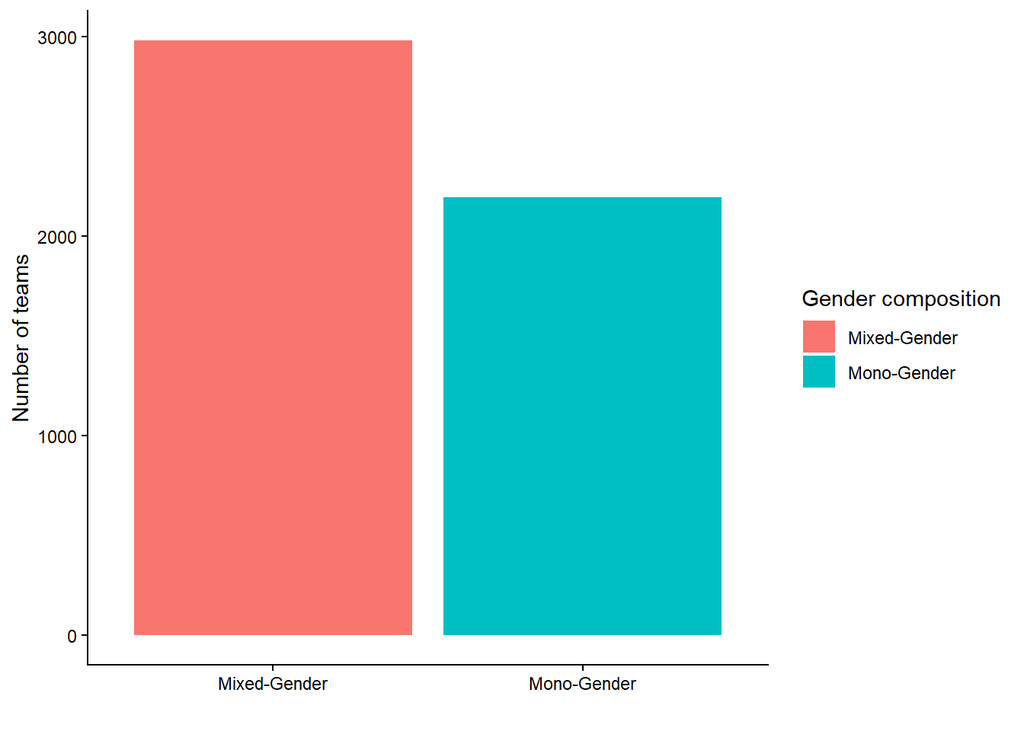

## Gender composition over the years

The increase in mixed-gender teams is more pronounced than in mono-gender ones.

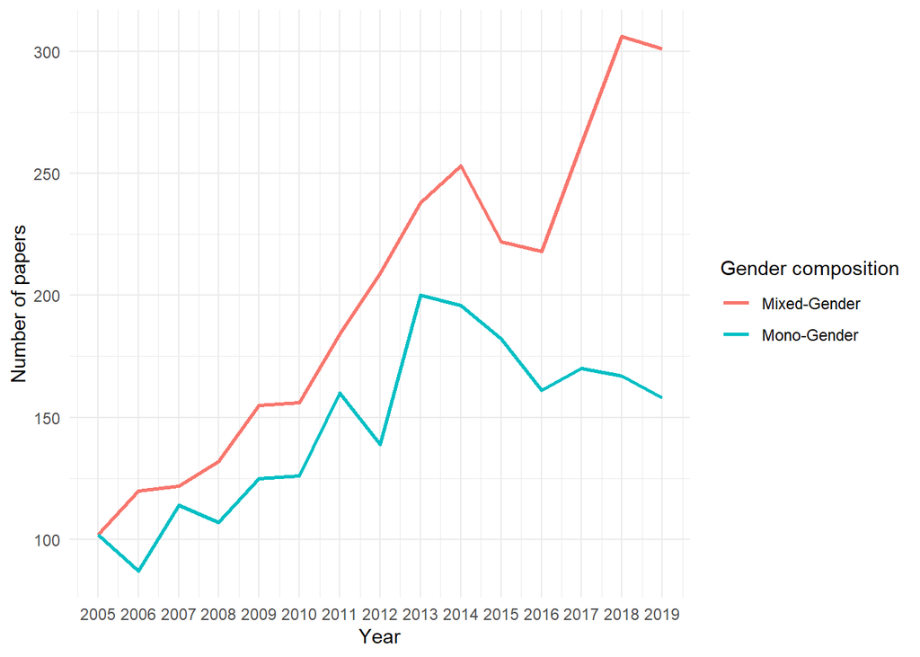

## Number of affiliations

The most frequent number of affiliations is 2: between-university collaborations are very widespread.

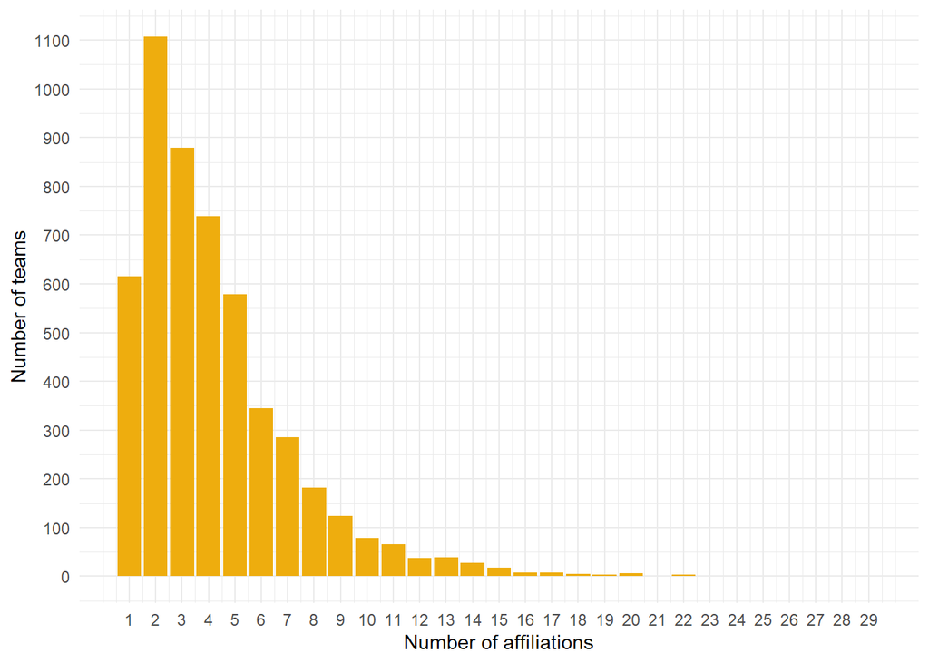

## Number of affiliations per year

There is a small increase of the mean number of universities over the years.

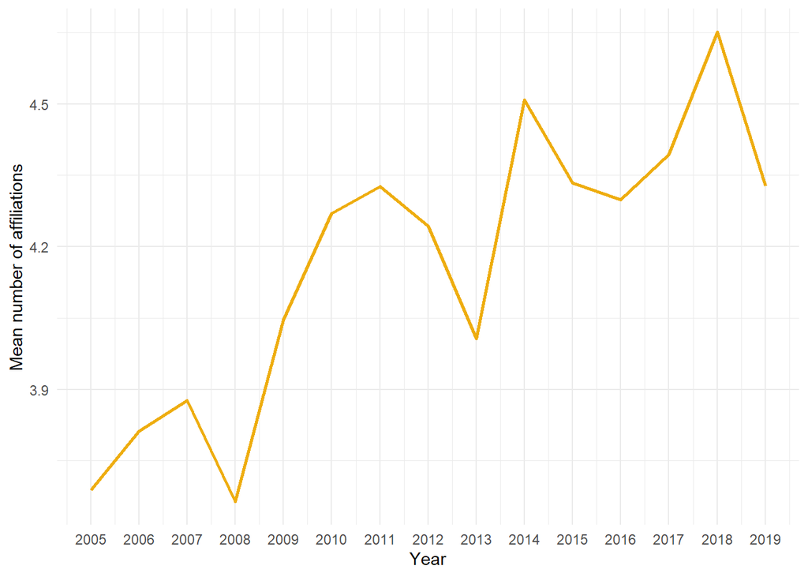

# Diversity indices

## Indices calculation

We use Shannon entropy to compute a diversity index for gender and for affiliation. Entropy is computed per article on the counts of contributors in each category (male/female for gender; institution for affiliation).

```r
# Counts are built in long format and passed to vegan::diversity() per article,
# instead of pivoting to a wide article x institution matrix and using rowwise().
# The index is the same; it is just much lighter on memory and time.

gender_div <- contributions %>%
  left_join(actor %>% select(H_ID, Gender), by = c("contributor" = "H_ID")) %>%
  filter(Gender %in% c("male", "female")) %>%
  count(UT, Gender, name = "n_gender") %>%
  group_by(UT) %>%
  summarise(gender_diversity = diversity(n_gender, index = "shannon"),
            .groups = "drop")

affiliation_div <- cont_with_aff %>%
  filter(!is.na(Inst_ID)) %>%
  count(UT, Inst_ID, name = "n_uni") %>%
  group_by(UT) %>%
  summarise(affiliation_diversity = diversity(n_uni, index = "shannon"),
            .groups = "drop")

diversity_tbl <- div_article %>%
  left_join(gender_div, by = "UT") %>%
  left_join(affiliation_div, by = "UT") %>%
  select(UT, n_conts, gender_diversity, affiliation_diversity, TC,
         Journal_Complete, Pub_Year)
```

## Correlation check

We check the correlation between the number of contributors and the diversity indices, to rule out multicollinearity problems in the model. There is a moderate correlation between affiliation diversity and the number of contributors, which should not be problematic.

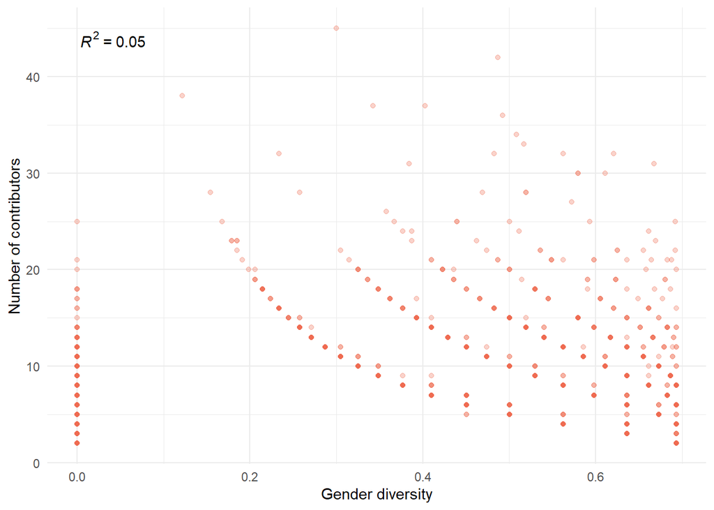

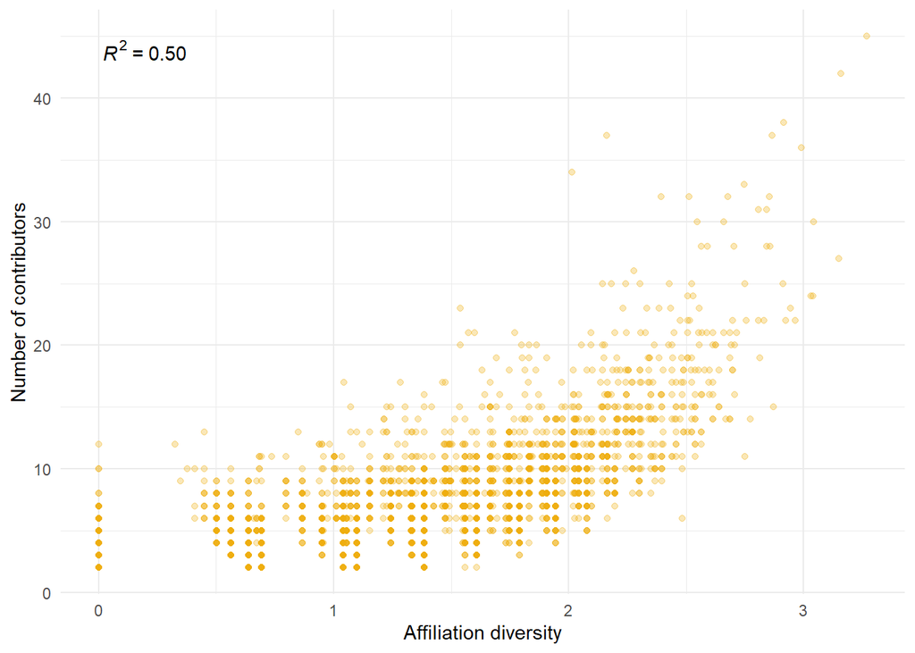

## Controls and final sample

We use journal, publication year and sub-field as fixed effects, and the number of contributors, prize winners and officials as controls.

```r
# Prize winners among the contributors
prize_count <- contributions %>%
  semi_join(prize, by = c("contributor" = "H_ID")) %>%
  group_by(UT) %>%
  summarise(n_prize_winners = n_distinct(contributor), .groups = "drop")

# Contributors holding official roles in associations
role_count <- contributions %>%
  semi_join(association, by = c("contributor" = "H_ID")) %>%
  group_by(UT) %>%
  summarise(n_official_roles = n_distinct(contributor), .groups = "drop")

# Sub-field clusters (coarse resolution)
clusters <- clustering %>%
  filter(Resolution == "Coarse") %>%
  select(UT, Cluster)

# We merge all data in a single table
art_div <- diversity_tbl %>%
  left_join(prize_count, by = "UT") %>%
  left_join(role_count, by = "UT") %>%
  mutate(n_prize_winners  = coalesce(n_prize_winners, 0),
         n_official_roles = coalesce(n_official_roles, 0)) %>%
  left_join(clusters, by = "UT")

# Joins must not duplicate articles
if (anyDuplicated(art_div$UT) > 0) {
  warning("art_div has duplicated UT values: check the joins (e.g. `clustering`).")
}

nrow(art_div)   # sample size check (5174 in the original run)
```

```
## [1] 5174
```

fixest silently drops rows with missing values in any variable used by a model, so models with different variables would end up on different samples (5,110 vs 5,122 rows in the original run), and AIC/BIC comparisons across them would not be valid. We therefore build **one common estimation sample** and use it for all models below.

```r
model_vars <- c("TC", "gender_diversity", "affiliation_diversity", "n_conts",
                "n_prize_winners", "n_official_roles",
                "Journal_Complete", "Pub_Year", "Cluster")

model_data <- art_div %>% drop_na(all_of(model_vars))

nrow(model_data)   # 5110 in the original run
```

```
## [1] 5110
```

A 10-row preview of the final table:

```r
model_data %>%
  select(-UT) %>%
  slice_head(n = 10) %>%
  reactable()
```

| n_conts | gender_diversity | affiliation_diversity | TC | Journal_Complete | Pub_Year | n_prize_winners | n_official_roles | Cluster |
| --- | --- | --- | --- | --- | --- | --- | --- | --- |
| 10 | 0.325082973391448 | 1.94591014905531 | 21 | ERKENNTNIS | 2005 | 0 | 0 | 3 |
| 2 | 0 | 0.636514168294813 | 13 | ERKENNTNIS | 2005 | 0 | 1 | 3 |
| 5 | 0 | 1.38629436111989 | 17 | ERKENNTNIS | 2005 | 0 | 0 | 3 |
| 3 | 0 | 1.09861228866811 | 15 | ERKENNTNIS | 2005 | 0 | 0 | 3 |
| 5 | 0 | 0 | 2 | ERKENNTNIS | 2005 | 0 | 0 | 2 |
| 8 | 0 | 1.27703425946614 | 10 | ERKENNTNIS | 2005 | 0 | 0 | 6 |
| 2 | 0 | 0 | 3 | ERKENNTNIS | 2005 | 0 | 0 | 4 |
| 3 | 0.636514168294813 | 1.03972077083992 | 39 | ERKENNTNIS | 2005 | 0 | 0 | 2 |
| 4 | 0.562335144618808 | 0.693147180559945 | 7 | ERKENNTNIS | 2005 | 0 | 0 | 6 |
| 15 | 0.673011667009257 | 2.30258509299405 | 1 | ERKENNTNIS | 2005 | 0 | 2 | 2 |

# Regression

## Model

We use a negative binomial regression with fixed effects. The dependent variable is the citation count; the independent variables are gender and affiliation diversity, with the controls and fixed effects described above.

```r
gender_and_affil_fenegbin <- fenegbin(
  TC ~ gender_diversity + affiliation_diversity + n_conts +
    n_prize_winners + n_official_roles
  | Journal_Complete + Pub_Year + Cluster,
  data = model_data
)
```

## Results

Here are the results of the model:

```r
summary(gender_and_affil_fenegbin, vcov = "iid")
```

```
## ML estimation, family = Negative Binomial, Dep. Var.: TC
## Observations: 5,110
## Fixed-effects: Journal_Complete: 8,  Pub_Year: 15,  Cluster: 9
## Standard-errors: IID
##                        Estimate Std. Error   z value   Pr(>|z|)
## gender_diversity       0.092815   0.054167  1.713518 8.6617e-02 .
## affiliation_diversity  0.185317   0.031437  5.894886 3.7494e-09 ***
## n_conts                0.015935   0.004717  3.378432 7.2900e-04 ***
## n_prize_winners       -0.028915   0.029813 -0.969873 3.3211e-01
## n_official_roles       0.057406   0.017317  3.314959 9.1657e-04 ***
## ---
## Signif. codes:  0 '***' 0.001 '**' 0.01 '*' 0.05 '.' 0.1 ' ' 1
## Over-dispersion parameter: theta = 0.9950958
## Log-Likelihood: -18,641.3   Adj. Pseudo R2: 0.027488
##            BIC:  37,581.5     Squared Cor.: 0.125884
```

To interpret the coefficients more easily we exponentiate them to obtain incidence rate ratios (IRR). An IRR of 1.10 indicates a 10% increase in expected citations for each one-unit increase in the predictor. The 95% confidence interval is reported as `IRR_low` (smallest plausible effect) and `IRR_high` (largest plausible effect).

```r
tidy(gender_and_affil_fenegbin, vcov = "iid", effects = "fixed", conf.int = TRUE) %>%
  mutate(
    IRR      = round(exp(estimate), digits = 4),
    IRR_low  = round(exp(conf.low), digits = 4),
    IRR_high = round(exp(conf.high), digits = 4)
  ) %>%
  mutate(stat_sing = case_when(
    p.value < 0.001 ~ "***",
    p.value < 0.01  ~ "**",
    p.value < 0.05  ~ "*",
    p.value < 0.1   ~ ".",
    TRUE            ~ ""
  )) %>%
  select(term, IRR, IRR_low, IRR_high, stat_sing) %>%
  reactable()
```

| term | IRR | IRR_low | IRR_high | stat_sing |
| --- | --- | --- | --- | --- |
| gender_diversity | 1.0973 | 0.9867 | 1.2202 | . |
| affiliation_diversity | 1.2036 | 1.1317 | 1.2801 | *** |
| n_conts | 1.0161 | 1.0067 | 1.0255 | *** |
| n_prize_winners | 0.9715 | 0.9164 | 1.03 |  |
| n_official_roles | 1.0591 | 1.0237 | 1.0956 | *** |
| .theta | 2.705 | 2.5996 | 2.8146 | *** |

# Gender diversity across disciplines

The effect of gender diversity is not significant overall. However, gender diversity varies between sub-fields that are cited to different extents: on average, the most gender-diverse sub-fields are also the most cited. (This comparison rests on about nine sub-fields and is purely descriptive.)

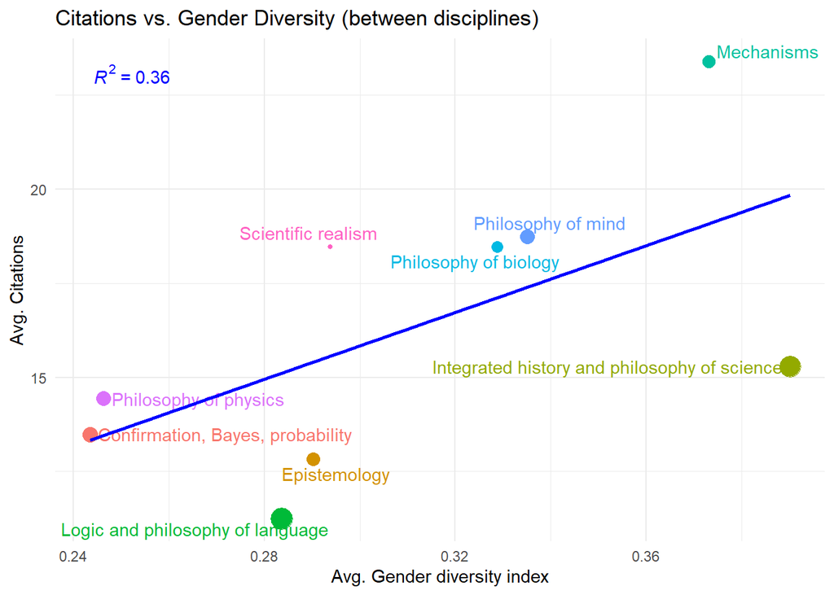

On the other hand, **within** a sub-field gender diversity is not associated with an increase in citations.

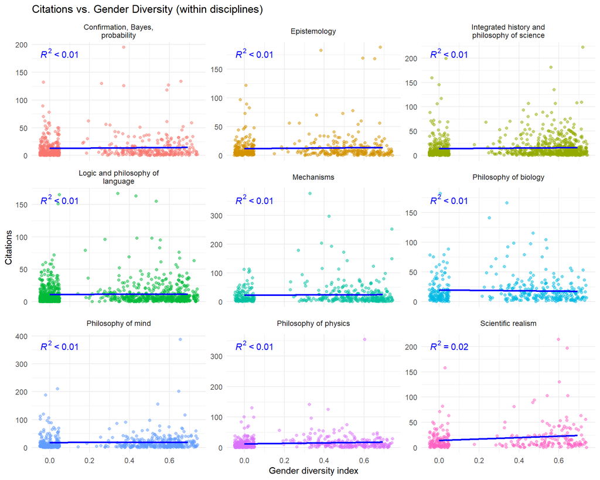

# Gender and affiliation have additive effects

We also inspect whether gender and affiliation diversity have additive effects. First, there is little correlation between the two.

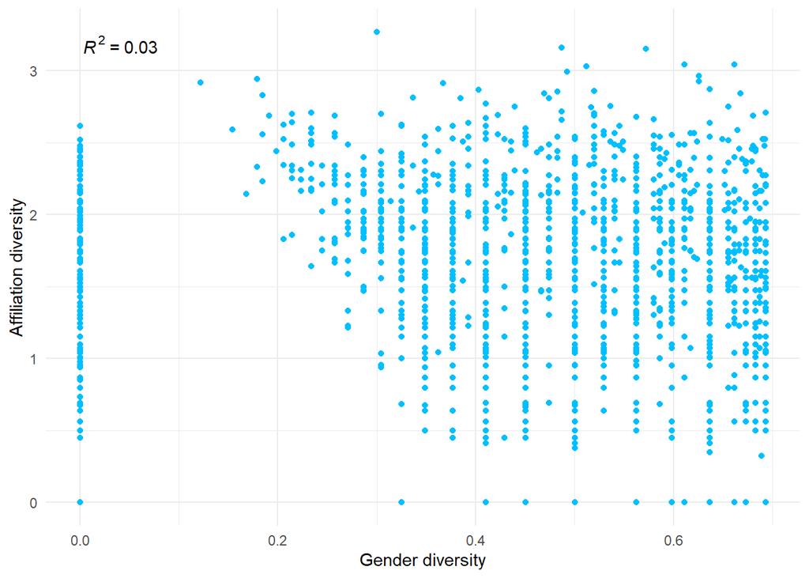

To further support this, we fit two more models, each with only one kind of diversity (same sample, same controls and fixed effects as above).

```r
gender_only_fenegbin <- fenegbin(
  TC ~ gender_diversity + n_conts + n_prize_winners + n_official_roles
  | Journal_Complete + Pub_Year + Cluster,
  data = model_data
)

affiliation_only_fenegbin <- fenegbin(
  TC ~ affiliation_diversity + n_conts + n_prize_winners + n_official_roles
  | Journal_Complete + Pub_Year + Cluster,
  data = model_data
)
```

Comparing the models:

```r
models <- list(
  "Gender and Affiliation" = gender_and_affil_fenegbin,
  "Gender diversity"       = gender_only_fenegbin,
  "Affiliation diversity"  = affiliation_only_fenegbin
)

modelsummary(models,
             vcov = "iid",
             stars = TRUE,
             statistic = "p.value",
             fmt = 5,
             gof_omit = "Std.Errors|FE")
```

|  | Gender and Affiliation | Gender diversity | Affiliation diversity |
| --- | --- | --- | --- |
| gender_diversity | 0.09282+ | 0.09785+ |  |
|  | (0.08136) | (0.05354) |  |
| affiliation_diversity | 0.18532** |  | 0.18612** |
|  | (0.00224) |  | (0.00215) |
| n_conts | 0.01594* | 0.03418*** | 0.01689* |
|  | (0.03696) | (0.00044) | (0.02754) |
| n_prize_winners | -0.02892 | -0.02232 | -0.02820 |
|  | (0.47673) | (0.58082) | (0.49330) |
| n_official_roles | 0.05741* | 0.07085* | 0.05889* |
|  | (0.02750) | (0.01381) | (0.02450) |
| Num.Obs. | 5110 | 5110 | 5110 |
| R2 | 0.029 | 0.028 | 0.029 |
| R2 Adj. | 0.027 | 0.027 | 0.027 |
| R2 Within | 0.008 | 0.007 | 0.008 |
| R2 Within Adj. | 0.007 | 0.007 | 0.007 |
| AIC | 37352.6 | 37385.1 | 37353.6 |
| BIC | 37581.5 | 37607.4 | 37575.9 |
| RMSE | 22.45 | 22.55 | 22.45 |

+ p < 0.1, * p < 0.05, ** p < 0.01, *** p < 0.001